# Understanding missing data in gapminder

# Developing an imputation model (not on the exam, just an illustration!)

We need to develop a model that predicts infant mortality accurately and yields few implausible (e.g. negative) values. If we have time, we will go through this together live - note that these are only the first few steps

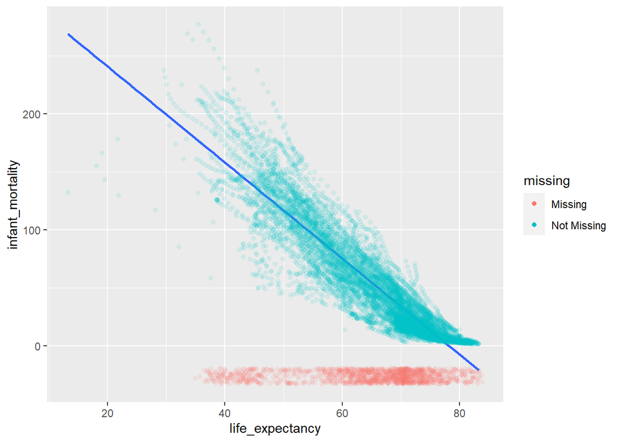

```r
# We could try predicting infant mortality from life expectancy. geom_miss_point() from naniar helps us to see in what range we would get imputations (the points along the x-axis are the ones we have missing values for on the y-variable) --> when you go up to the line from the red points, you see the imputed values you would get - main issue here is that we would get too many below zero, for life expectancies above 78, which are obviously impossible
ggplot(gapminder, aes(x = life_expectancy, y = infant_mortality)) +
  geom_smooth(method = "lm", se = FALSE) +
  geom_miss_point(alpha = .1)
```

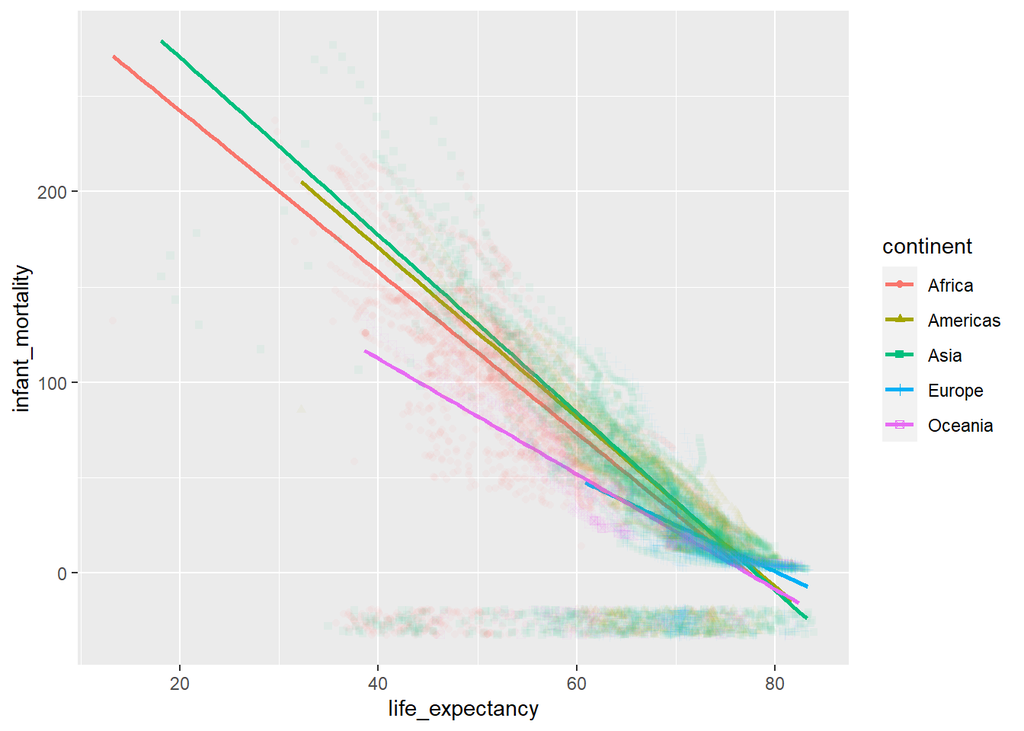

```r
# Maybe we can get more realistic values by considering continents? --> this makes it worse for Asia, so maybe region or so is better
ggplot(gapminder, aes(x = life_expectancy, y = infant_mortality,
                      colour = continent)) +
  geom_smooth(method = "lm", se = FALSE) +
  geom_miss_point(alpha = .05, aes(shape = continent))
```

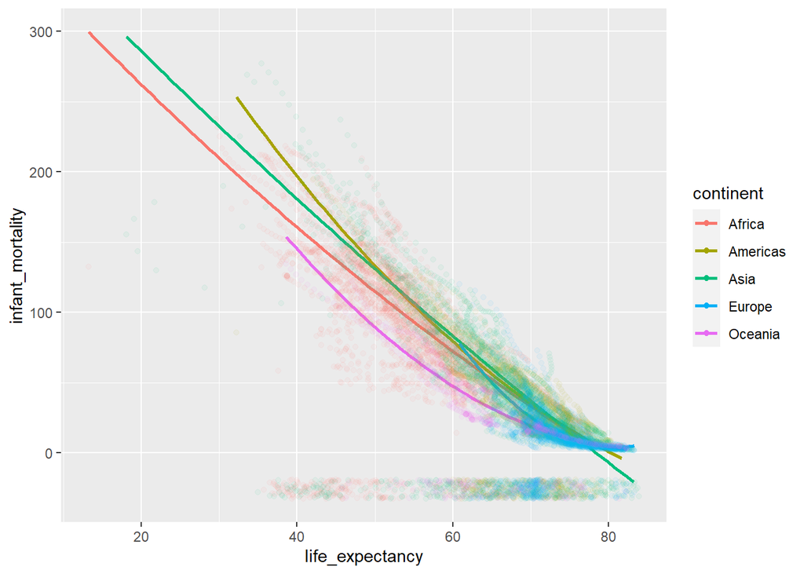

```r
# OPTIONAL EXTENSION: We could also recognise that the relationship won't be linear, but that the strength of the relationship will decrease with increasing life expectancy. We have not covered that, but one way to test that is to add a quadratic term to the linear regression equation (if you remember that a y = x^2 graph looks like an U, you might see that adding a part of that U to our straight line will result in a curved line) - that makes the situation better for continents with very different countries, i.e. Oceania --> we could continue this model building until we have found a reasonable (!!) well-fitting model

ggplot(gapminder, aes(x = life_expectancy, y = infant_mortality,
                      colour = continent)) +
  geom_smooth(method = "lm", formula = "y ~ x + I(x^2)", se = FALSE) +
  geom_miss_point(alpha = .05)
```

This shows that developing a good imputation model can take a while, which makes casewise deletion attractive in practice. If you use casewise deletion, at least make sure to report how much missing data you have and whether it can be assumed to be missing completely at random.

If we settle on an imputation model, we can use simputation to model it. Note that I run multiple models subsequently to use gdp_per_capita where it is available.

```r
library(simputation)
```

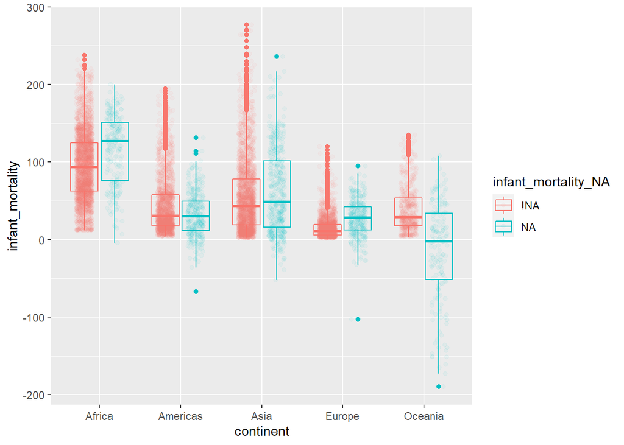

```r
gapminder <- gapminder %>%
  impute_lm(infant_mortality ~ life_expectancy * region * log(gdp_per_capita),
            add_residual = "observed") %>%
  impute_lm(infant_mortality ~ life_expectancy * region,
            add_residual = "observed")

# Let's check if the imputed values generally make sense
ggplot(gapminder, aes(x = continent, y = infant_mortality, color = infant_mortality_NA)) +
  geom_jitter(alpha = .05, position=position_jitterdodge()) +
  # position_jitterdodge moves the points away from each other (jitter) and
  # in line with the boxplots (dodge) / take it out to see the difference
    geom_boxplot(fill = NA)
```

This looks ok, apart from Oceania - ideally, we would figure out how to improve the predictions. In the end, we need to set 0 as the lower bound and set all imputed values below to 0.